# STATS 769 Lab 06

## The Data

The data are provided in a single 1.3G CSV file containing 6.5 million trips.

The CSV file is located on each VM at the location `/course/data.austintexas.gov/Dockless_Vehicle_Trips.csv`.

```bash
head -4 /course/data.austintexas.gov/Dockless_Vehicle_Trips.csv
```

```
ID,Device ID,Vehicle Type,Trip Duration,Trip Distance,Start Time,End Time,Modified Date,Month,Hour,Day of Week,Council District (Start),Council District (End),Year,Census Tract Start,Census Tract End
6865731e-5e4b-4819-9435-4e62e09a652d,08c8c852-257c-49ad-a14f-727bfc79626d,,,,,,12/13/2018 03:36:12 PM,,,,0,0,,,
08dc0d9c-735e-4006-b9af-60011509e469,255716b5-4a9f-4efc-9967-7a65b3521bac,bicycle,11491603,1658,11/30/2018 11:00:00 AM,04/12/2019 12:00:00 PM,12/21/2018 12:41:42 AM,11,11,5,9,0,2018,,
aa27d854-9f27-456e-ae49-f268a9b2b533,6b90a827-60a1-47ad-94a4-d33654dbd50d,scooter,170,0,04/29/2019 05:30:00 PM,04/29/2019 05:30:00 PM,04/30/2019 06:45:17 AM,4,17,1,9,9,2019,48453000601,48453000601
```

## Import

We will not load the entire data set into R; instead we are going to explore the size of small subsets of the CSV file and extrapolate to estimate the size of the full data set.

We read in 1000, 10000, and 100000 rows of the data set into R and look at the size of the resulting data frames.

```r
tripsSmall <- read.csv("/course/data.austintexas.gov/Dockless_Vehicle_Trips.csv",
                     nrows=1000)
tripsMedium <- read.csv("/course/data.austintexas.gov/Dockless_Vehicle_Trips.csv",
                      nrows=10000)
tripsLarge <- read.csv("/course/data.austintexas.gov/Dockless_Vehicle_Trips.csv",
                       nrows=100000)
```

```r
object.size(tripsSmall)
```

```
292912 bytes
```

```r
object.size(tripsMedium)
```

```
2618864 bytes
```

```r
object.size(tripsLarge)
```

```
19503648 bytes
```

It looks like, very roughly, 20MB per 100000 rows, which suggests a full data frame size of a little over 1GB (very similar to the size of the data set on disk in this case).

Looking at the classes of the columns that R creates, the variables we will be most interested in are integers. At 6.5 million observations, these columns will be in the region of 25MB. Any calculation involving those variables could easily double that to 50MB if the result becomes numeric (rather than integer).

```r
sapply(tripsSmall, class)
```

```
                      ID                Device.ID             Vehicle.Type
                "factor"                 "factor"                 "factor"
           Trip.Duration            Trip.Distance               Start.Time
               "integer"                "integer"                 "factor"
                End.Time            Modified.Date                    Month
                "factor"                 "factor"                "integer"
                    Hour              Day.of.Week Council.District..Start.
               "integer"                "integer"                "integer"
  Council.District..End.                     Year       Census.Tract.Start
               "integer"                "integer"                "numeric"
        Census.Tract.End
               "numeric"
```

The largest contributors to the data frame size are the factor columns. This is because the level labels of the factors are also stored and, for some factors at least, there are many different levels (the worst is `ID`, where every value is unique; compare that to the `Vehicle.Type` factor, which only has a few different levels).

```r
sapply(tripsLarge, object.size)
```

```
                      ID                Device.ID             Vehicle.Type
                10800432                  2211488                   400632
           Trip.Duration            Trip.Distance               Start.Time
                  400048                   400048                   652528
                End.Time            Modified.Date                    Month
                  649448                   768976                   400048
                    Hour              Day.of.Week Council.District..Start.
                  400048                   400048                   400048
  Council.District..End.                     Year       Census.Tract.Start
                  400048                   400048                   408200
        Census.Tract.End
                  409640
```

The `Time` and `Date` variables should not be factors and if we stored them as times and dates in R they would be significantly smaller (because dates are stored just as numbers of days or numbers of seconds since an origin).

## Tidy

The very first row of data contains missing values, so we will exclude that.

```r
head(tripsLarge, 1)
```

```
                                    ID
1 6865731e-5e4b-4819-9435-4e62e09a652d
                             Device.ID Vehicle.Type Trip.Duration
1 08c8c852-257c-49ad-a14f-727bfc79626d                         NA
  Trip.Distance Start.Time End.Time          Modified.Date Month Hour
1            NA                     12/13/2018 03:36:12 PM    NA   NA
  Day.of.Week Council.District..Start. Council.District..End. Year
1          NA                        0                      0   NA
  Census.Tract.Start Census.Tract.End
1
```

There is at least one very value in both distance and duration.

```r
tail(sort(tripsLarge$Trip.Distance))
```

```
[1]    78467    83979   138355   160254   415600 15096088
```

```r
tail(sort(tripsLarge$Trip.Duration))
```

```
[1]    45970    51826    54482    59759    80890 11491603
```

We will exclude a further three observations; the largest duration and the two largest distances.

```r
tripsKeep <- tripsLarge[-c(1, which.max(tripsLarge$Trip.Duration),
                           order(tripsLarge$Trip.Distance,
                                 decreasing=TRUE)[1:2]), ]
```

## Transform

Using 100000 trips, we remove non-positive durations and distances and then log both variables.

We consider two approaches to the transformation: (A) use `subset()` and create new variables within the `trips` data frame; and (B) calculate a simple logical vector for subsetting and create new variables separate from the `trips` data frame. In both cases, we use a function `topmem()` (not shown) that prints the result of `profmem::profmem()` to look at the largest individual R objects being created, and we use a function `maxmem()` (not shown) that extracts values from `gc()` to look at the maximum overall memory used by R.

```r
mem1 <- gc(reset=TRUE)
p <- profmem({
    trips <- subset(tripsKeep, Trip.Duration > 0 & Trip.Distance > 0)
    trips$logDuration <- log(trips$Trip.Duration)
    trips$logDistance <- log(trips$Trip.Distance)
})
mem2 <- gc()
```

The results for option A show that the largest R objects created are only on the order of one or two columns of 100,000 values, but the largest amount of memory used at one time was nearly 24MB. This suggests that there are lots of intermediate values being generated by `subset()`.

```r
topmem(p)
```

```
             FUN    Bytes
1         subset  1048624
2     <internal>   751688
3     <internal>   751688
4         subset   400040
5         subset   400040
6         subset   400040
N                      84
TOTAL            24554984
```

```r
maxmem(mem1, mem2)
```

```
[1] 23.9
```

```r
mem1 <- gc(reset=TRUE)
p <- profmem({
    subset <- tripsKeep$Trip.Duration > 0 & tripsKeep$Trip.Distance > 0
    logDuration <- log(tripsKeep$Trip.Duration[subset])
    logDistance <- log(tripsKeep$Trip.Distance[subset])
})
mem2 <- gc()
```

The results for option B show that the largest R objects created are similar to option A, but the largest amount of memory used at one time was only 5MB. Extrapolating to the full data set, option A might consume a maximum memory of around 1.5GB, while option B might only require a little over 300MB.

```r
topmem(p)
```

```
             FUN   Bytes
1     <internal>  751688
2     <internal>  751688
3     <internal>  400040
4     <internal>  400040
5     <internal>  400032
6     <internal>  400032
N                     11
TOTAL            5007040
```

```r
maxmem(mem1, mem2)
```

```
[1] 5
```

These transformations leave us with 93955 trips for the modelling phase.

## Model

We will consider a simple linear regression model and estimate test accuracy using k-fold cross-validation and we will measure the maximum memory usage.

```r
labels <- rep(1:10, length.out=length(logDuration))
groups <- sample(labels)
mse <- function(i, formula) {
    testSet <- groups == i
    trainSet <- groups != i
    fit <- lm(formula,
              data.frame(x=logDistance[trainSet], y=logDuration[trainSet]))
    pred <- predict(fit, data.frame(x=logDistance[testSet]))
    mean((pred - logDuration[testSet])^2, na.rm=TRUE)
}
```

This code uses a maximum memory of around 55MB.  
This extrapolates to peak memory requirements, for the full data set, of around 3.5GB.

```r
mem1 <- gc(reset=TRUE)
mean(sapply(1:10, mse, y ~ x))
```

```
[1] 0.3349429
```

```r
mem2 <- gc()
```

```r
maxmem(mem1, mem2)
```

```
[1] 55.4
```

Here is a plot of the regression model fit to the entire data set.

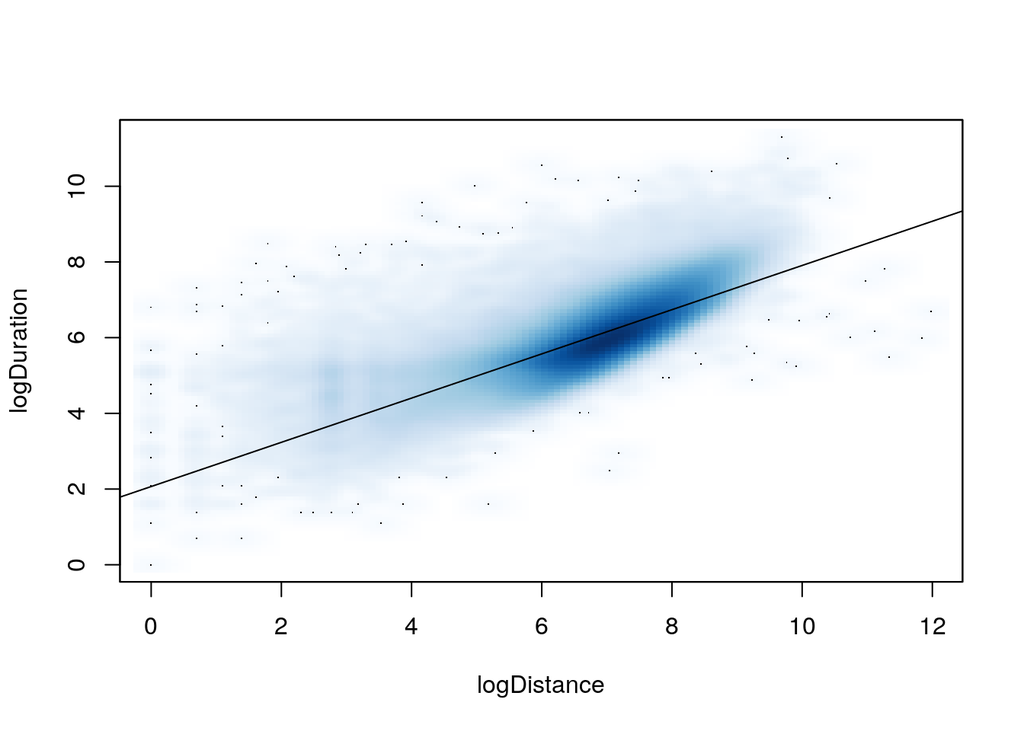

```r
smoothScatter(logDuration ~ logDistance)
abline(lm(logDuration ~ logDistance))
```

## Overall memory available and used

Note that the total memory used for all persistent R objects is now only in the region of 40MB, but the peak memory usage overall was close to 100MB (corresponding to about 2.5GB and 6.5GB respectively for the full data set). On the other hand, we have generated several unnecessary copies of some of the data (e.g., the logged durations and distances are held in both the `trips` data frame and in separate vectors), so this worst-case scenario could be an overestimate.

```r
gc()
```

```
          used (Mb) gc trigger (Mb) max used (Mb)
Ncells  699993 37.4    1219998 65.2   779030 41.7
Vcells 5368066 41.0   12621527 96.3 12621527 96.3
```

Each VM has approximately 200GB of RAM, which provides plenty of room for this analysis on the full data set. However, if 40 students were all trying to perform this analysis on the same VM, we might run out of RAM.

```bash
free -g
```

```
              total        used        free      shared  buff/cache   available
Mem:            196           1         188           0           7         194
Swap:             3           0           3
```

The shell command `time` reports almost 200MB required to process this report.

```
/usr/bin/time -f "%M" Rscript -e 'rmarkdown::render("lab06-model.Rmd")'
```

```
187364
```

That is higher than the measurements we made when just running the R code to transform the data and estimate test error, but, for example, we did not take into account the memory that R itself uses (e.g., the `Ncells` in `gc()` output) and the ‘rmarkdown’ package will use additional memory when processing the report.

## Conclusion

The data source for this lab was a single CSV file over 1GB in size.

We only loaded subsets of this file into R in order to assess the memory requirements for working with the data.

Two approaches to transforming the data showed that there are sometimes (memory) costs to using higher-level convenience functions like `subset()`.

The worst case memory requirements for fitting even a simple linear regression model to the full data would be very taxing even for a modern PC with 8GB of RAM. The VM, with 200GB RAM would have no trouble with this task, but if 40 students attempted the task simultaneously even the VM would struggle.